# Bayes Homework1

2020311198 Dongook Son

# Chapter 1

## 1.

> Conditional probability: suppose that if $\theta = 1$, then $y$ has a normal distribution with mean 1 and standard deviation $\sigma$ , and if $\theta = 2$, then $y$ has a normal distribution with mean 2 and standard deviation $\sigma$ . Also, suppose $Pr(\theta=1)=0.5$ and $Pr(\theta = 2) = 0.5$.

### (a)

> For $\sigma=2$, write the formula for the marginal probability density for $y$ and sketch it.

Prior distribution :
$$\pi(\theta)=0.5 \ where \ \theta \in \{1,2\}$$
Marginal distribution :
$$\begin{aligned}
p(y) &= \pi(\theta=1) p(y \mid \theta=1)+\pi(\theta=2) p(y \mid \theta=2) \\
&=0.5 \frac{1}{2 \sqrt{2 \pi}} e^{-\frac{1}{2}\left(\frac{y-1}{2}\right)^{2}}
+0.5 \frac{1}{2 \sqrt{2 \pi}} e^{-\frac{1}{2}\left(\frac{y-2}{2}\right)^{2}} \\
&=\frac{1}{4 \sqrt{2 \pi}} ( e^{-\frac{1}{2}\left(\frac{y-1}{2}\right)^{2}} + e^{-\frac{1}{2}\left(\frac{y-2}{2}\right)^{2}})
\end{aligned}$$

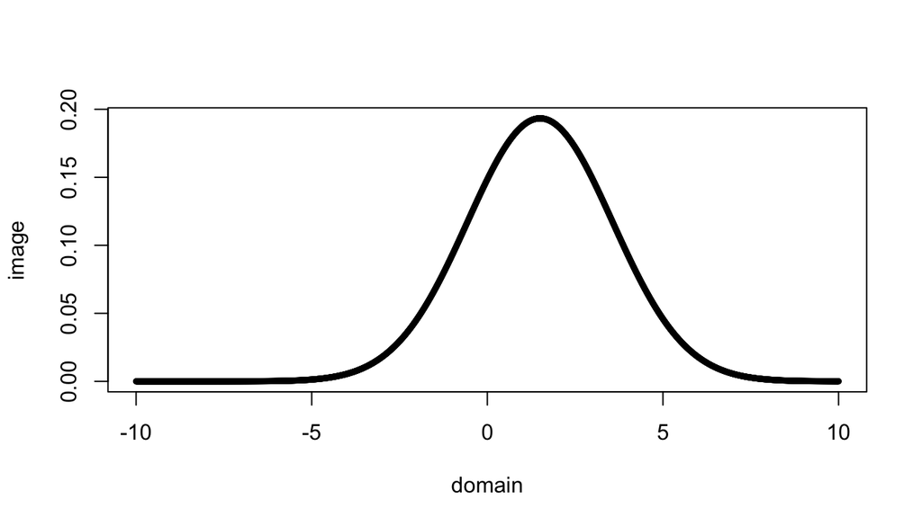

```r
domain <- seq(-10,10,0.01)
image <- 0.5*(dnorm(domain,1,2) + dnorm(domain,2,2))
plot(domain, image, cex=0.5)
```

### (b)

> What is $Pr(\theta=1|y=1)$, again supposing $\sigma=2$?

By using the Bayes theorem,

$$\begin{aligned}
Pr(\theta=1|y=1) &= \frac{Pr(y=1|\theta=1)\pi(\theta=1)}{\sum_{\theta=1}^{2}Pr(y=1|\theta)\pi(\theta )} \\
&=\frac{0.5 \frac{1}{2 \sqrt{2 \pi}}}{0.5 \frac{1}{2 \sqrt{2 \pi}}
(1+e^{-\frac{1}{2}\left(\frac{1-2}{2}\right)^{2} })} \\
&= \frac{1}{1+\exp(-1/8)} \\
&= 0.5312
\end{aligned}$$

```r
1/(1+exp(-1/8))
```

```
## [1] 0.5312094
```

### (c)

> Describe how the posterior density of $\theta$ changes in shape as $\sigma$ is increased and as it is decreased.

As $\sigma \to \infty$, the posterior density of $\theta$(i.e. $Pr(\theta|y, \sigma )$ ) converges to 0.5. On the other hand as $\sigma \to 0$, the posterior density converges to 1.  
When the variance is vastly large, this implies that the collected data is non-informative hence similar to the prior distribution. But, when the varaince is close to zero it means that the posterior density is a highly decisive function.

## 2.

> Conditional means and variances: show that (1.8) and (1.9) hold if $u$ is a vector.

Expectation of a vector of random variables stay as a vector, while the variance result in a covariance matrix.

In other words, the expectation can be viewed as a mapping of a vector with $n$ random variables to $\mathbb{R}^n$. Therefore it is obvious that the following holds.

The law of total expectation holds componentwise for $\forall u_i, i \in \{1,2,...,n\}$

$$\begin{aligned}
u = (u_1,u_2,...,u_n), n \in \mathbb{N} \\
E(u_i) = E(E(u_i|v)) \\
E(u) = E(E(u|v))
\end{aligned}$$

The variance of a vector, on the other hand, sends $n$ random variables to a $n \times n$ matrix. In other words it is a mapping of $\mathbb{R}^n$ to $\mathbb{R}^n \times \mathbb{R}^n$.

$$\begin{aligned}
Var(u) &= Cov(u_i, u_j ) \ where \ i,j \in \mathbb{N} \\
&= E(u_iu_j) - E(u_i)E(u_j) \\
&= E(u_iu_j) - E(E(u_i|v))E(E(u_j|v)) \\
&= E(u_iu_j) - E(E(u_i|v)E(u_j|v)) \\
&+E(E(u_i|v)E(u_j|v)) - E(E(u_i|v))E(E(u_j|v)) \\
&=E[E(u_iu_j|v) - E(u_i|v)E(u_j|v)] \\
&+E(E(u_i|v)E(u_j|v)) - E(E(u_i|v))E(E(u_j|v)) \\
&=E(Cov(u_i, u_j | v)) \\
&+ Cov(E(u_i|v),E(u_j|v))
\end{aligned}$$
Note that if $i = j$ then $Cov(u_i,u_j) = Var(u_i) = E(Var(u_i|v)) + Var(E(u_i|v))$

## 3.

> Assuming random mating, show that among brown-eyed children of brown-eyed parents, the expected proportion of heterozygotes is 2p/(1 + 2p).

> Suppose Judy, a brown-eyed child of brown-eyed parents, marries a heterozygote, and they have n children, all brown-eyed. Find the posterior probability that Judy is a heterozygote and the probability that her first grandchild has blue eyes.

> | Parents Combination | Parent $Pr$ | Child $Pr$ |
> | --- | --- | --- |
> | 2 hetero | $4p^2(1-p)^2$ | blue:1/4, hetero:1/2, non-hetero brown:1/4 |
> | 1 hetero 1 non-hetero brown | $2p(1-p)^3$ | hetero:1/2, non-hetero brown:1/2 |
> | 2 non-hetero brown | $(1-p)^4$ | non-hetero brown:1 |

$$\begin{aligned}
&P(child:hetero|child:brown, parent:brown) \\
&= \frac{P(child:hetero, child:brown|parent:brown)}{P(child:brown|parent:brown)} \\
&= \frac{P(child:hetero|parent:brown)}{P(child:brown|parent:brown)} \\
&= \frac{0.5 * 4p^2(1-p)^2 + 0.5*2p(1-p)^3}{0.75*4p^2(1-p)^2 + 2p(1-p)^3 + (1-p)^4} \\
&= \frac{2p}{1+2p}
\end{aligned}$$

$$\begin{aligned}
&Pr(Judy:hetero|n-children: brown) \\
&= \frac{Pr(n-children:brown|Judy:hetero)Pr(Judy:hetero)}{Pr(n-children:brown|Judy:hetero)Pr(Judy:hetero)+ Pr(n-children:brown|Judy:XX)Pr(Judy:XX)} \\
&= \frac{\frac{2 p}{1+2 p} * \left(\frac{3}{4}\right)^{n}}{\frac{2 p}{1+2 p} *\left(\frac{3}{4}\right)^{n}+\frac{1}{1+2 p} * 1}
\end{aligned}$$

For Judy’s grandchild to have blue eyes, her children must be a heterozygote since all her children have brown eyes.
$$\begin{aligned}
&Pr(Child:hetero|all \ data) \\
&= Pr(Judy:hetero, Child:hetero \ or \ Judy:XX, Child:hetero | all \ data) \\
&=\frac{\frac{2 p}{1+2 p} * \left(\frac{3}{4}\right)^{n}}{\frac{2 p}{1+2 p} * \left(\frac{3}{4}\right)^{n}+\frac{1}{1+2 p}}\left(\frac{2}{3}\right)+\frac{\frac{1}{1+2 p}}{\frac{2 p}{1+2 p} * \left(\frac{3}{4}\right)^{n}+\frac{1}{1+2 p}}\left(\frac{1}{2}\right)
\end{aligned}$$

By the table illustrated above, since Judy’s child is a heterozygote, for the grandchild to have blue eyes the spouse must also be a heterozygote.

| Spouse | probability | Grandchild:Blue probability |
| --- | --- | --- |
| blue | $p^2$ | blue:1/2, hetero:1/2 |
| hetero | $2p(1-p)$ | blue:1/4, hetero:1/2, XX:1/4 |
| XX | $(1-p)^2$ | hetero:1/2, XX:1/2 |

$$Pr(Grandchild:blue|\text{all data}) \\
= Pr(child:hetero|\text{all data})*(\frac{1}{4} 2 p(1-p)+\frac{1}{2} p^{2}) \\
= Pr(child:hetero|\text{all data})*\frac{p}{2}$$

## 4.

### (a)

> Estimate each of these using the relative frequencies of games with a point spread of 8.

$$Pr(\text{favorite wins}|spread=8) \\
=\frac{\text{\# of favorite wins with spread 8}}{\text{\# of outcomes with spread 8}} \\
= \frac{8}{12}$$

$$Pr(\text{favorite wins by at least 8}|spread=8) \\
= \frac{\#\{13,15,16,20,21\}}{12} \\
= \frac{5}{12}$$

$$Pr(\text{favorite wins by at least 8}|spread=8, \text{favorite wins}) \\
=\frac{\#\{13,15,16,20,21\}}{\#\{1,6,7,13,15,16,20,21\}} \\
= \frac{5}{8}$$

### (b)

> Estimate each using the normal approximation for the distribution of (outcome - point spread).

I will use parameters provided from example 1.6.

$$d = \text{outcome - point spread} \sim N(0,14^2)$$
Note that ‘favorite wins’ can be interpreted as $outcome + spread > 8$. 0.5 is added due to the continuity correction for discrete data to Normal approximation.

$$Pr(\text{favorite wins | spread=8}) = \Phi(\frac{8+0.5}{14})$$
$$Pr(\text{favorite wins by at least 8| spread=8}) = \Phi(\frac{0.5}{14})$$
$$Pr(\text{favorite wins by at least 8| spread=8, favorite wins}) = \frac{Pr(\text{favorite wins by at least 8| spread=8})}{Pr(\text{favorite wins | spread=8})} \\
= \frac{\Phi(\frac{0.5}{14})}{\Phi(\frac{8+0.5}{14})}$$

## 5.

### (a)

> Use any knowledge you have about U.S. politics. Specify clearly what information you are using to construct this conditional probability, even if your answer is just a guess.

The election in the US usually is a competition between the Republican and Democratic candidates. We can set $n$ as the total number of votes in an individual election. Let’s think of an extreme case where $n=2$. Then the probability of election being tied in this case would be $1/2$. A tie happening in a voting situation will be as scarce as the number of voters. Therefore we can expand this case to $n:300,000$ and assume that the election resulting in a tie be $1/300,000$. If we think $y$ as the number of votes for the Republican candidates the relation follows.
$$2*y = n$$
$$Pr(2*y -n = 0) = Pr(\text{tie happening})$$
$$Pr(\text{No tie happening}) = 1- \frac{1}{300000}$$
$$Pr(\text{No tie happening for all elections}) = (1- \frac{1}{300000})^{435}$$
$$Pr(\text{at least one tie happening for all elections}) =1 - (1- \frac{1}{300000})^{435}$$

### (b)

> Use the following information: in the period 1900–1992, there were 20,597 congres- sional elections, out of which 6 were decided by fewer than 10 votes and 49 decided by fewer than 100 votes.

We can consider the 49 cases decided by fewer than 100 votes as a tie.
$$Pr(2*y -n =0) \sim Pr(|2*y -n| \le 100) = \frac{49}{20597}$$
$$Pr(\text{at least one tie happening for all elections}) =1 - (1- \frac{49}{20597})^{435}$$

## 6.

$$\begin{aligned}
&Pr(\text{identical twins|twin brothers}) \\
&= \frac{Pr(\text{identical twins, twin brothers})}{Pr(\text{identical twins, twin brothers})
+ Pr(\text{fraternal twins, twin brothers})} \\
&= \frac{\frac{1}{300} * 1/2}{ \frac{1}{300} * 1/2+ \frac{1}{125} * 1/4}
\end{aligned}$$

$$Pr(\text{fraternal twins, twin brothers}) \\
=Pr(\text{fraternal twins})Pr(\text{twin brothers|fraternal twins}) \\
= \frac{1}{125} * 1/4$$

$$Pr(\text{identical twins, twin brothers}) \\
=Pr(\text{identical twins})Pr(\text{twin brothers|identical twins}) \\
= \frac{1}{300} * 1/2$$

## 8.

### (a)

In this case A and B assigning different probabilities on the event that ‘6’ appearing on a fair die is unlikely. Since a fair dice has 6 equal spaces with only the number on the surface varying, two rational persons A and B would both assign the same probability.
$$P_{A}(E)=P_{B}(E) = \frac{1}{6}$$

### (b)

In an extreme case, when $n$ represents the number of countries participating in the World Cup and $E$ being the event Brazil winning, $A$ would assume $P_A(E) = \frac{1}{n}$ on the grounds that it is a game with fixed outcomes just like rolling a dice. $B$ on the other hand would assign $P_B(E) > \frac{1}{n}$ or $P_B(E) < \frac{1}{n}$ considering the players condition, opponent’s strategy and other key variables.

## 9.

```r
bda_example_1_9_simulation <- function(samples=100){
  ### simulation function for example 1.9
  ir_time <- rexp(samples, 1/10)  # Interarrival time generated from Exp(1/10)

  arrived_time <- c()  # Arrived time
  for(i in 1:samples){arrived_time[i]<-(sum(ir_time[seq(i)]))}

  doctor_time <- runif(samples, 5, 20)  # Doctor time generated from Unif(5,20)

  out_time <- rep(0,samples)  # Leaving time
  out_time[1] <- arrived_time[1] + doctor_time[1]  # First entity
  out_time[2] <- arrived_time[2] + doctor_time[2]  # Second entity
  out_time[3] <- arrived_time[3] + doctor_time[3]  # Third entity
  # Until third entity arrives, there is 0 wait time.

  worker <- rep(0, samples)  # Number of doctors seeing patient
  worker[1] <- 1  # First doctor occupied

  wait_time <- rep(0, samples)  # Wait time

  df = data.frame(ir_time, arrived_time, doctor_time, out_time, worker, wait_time)
  # Dataframe

  # Simulation
  for(i in 2:samples){

  df$worker[i] <- i - sum(df$arrived_time[i] > df$out_time[seq(i-1)])
  # Count working doctors

  if(df$worker[i] <= 3) {
    # No waiting Case
    df$out_time[i] <- df$arrived_time[i] + df$doctor_time[i]
    }

  else {
    # Waiting Case
    df$worker[i] <- 3
    df$wait_time[i] <- abs(max(df$arrived_time[i]
                               - df$out_time[seq(i-1)][(df$arrived_time[i]
                                                        - df$out_time[seq(i-1)] < 0)]))
    df$out_time[i] <- df$arrived_time[i] + df$wait_time[i] + df$doctor_time[i]
    }
  }


# Cut off simulation results that exceeds 480 minutes
  res <- df[df$arrived_time <= 420,]
  return(res)
}
```

### (a)

> Simulate this process once. How many patients came to the office? How many had to wait for a doctor? What was their average wait? When did the office close?

```r
set.seed(1111)
result <- bda_example_1_9_simulation()
nrow(result)
```

```
## [1] 47
```

47 patients came to the office.

```r
(waited_patients = sum(result$wait_time > 0))
```

```
## [1] 15
```

15 patients had to wait for a doctor.

```r
sum(result$wait_time[result$wait_time > 0]) / waited_patients
```

```
## [1] 2.605127
```

Their average wait was 2.61 minutes.

```r
result$out_time[nrow(result)]
```

```
## [1] 437.8718
```

Officed closed after 437.87 minutes since opening. Approximately 4:18pm.

### (b)

> Simulate the process 100 times and estimate the median and 50% interval for each of the summaries in (a).

Simulate 100 times.

```r
# Simulate 100 times and store it in list.
result_list <- list()
for (i in 1:100) {
  result_list[[i]] <- bda_example_1_9_simulation()
}
```

Store statistics for 100 simulations.

```r
num_patients <- c()
waited_patients <- c()
avg_wait_time <- c()
closed_time <- c()

for (i in 1:100) {
  num_patients[i] <- nrow(result_list[[i]])
  waited_patients[i] <- sum(result_list[[i]]$wait_time > 0)
  avg_wait_time[i] = sum(result_list[[i]]$wait_time[result_list[[i]]$wait_time > 0]) /
    waited_patients[i]
  closed_time[i] = result_list[[i]]$out_time[nrow(result_list[[i]])]
}
```

```r
summary(num_patients)
```

```
##    Min. 1st Qu.  Median    Mean 3rd Qu.    Max.
##   24.00   38.00   43.00   42.48   47.00   59.00
```

```r
summary(waited_patients)
```

```
##    Min. 1st Qu.  Median    Mean 3rd Qu.    Max.
##     0.0     3.0     5.5     6.1     9.0    21.0
```

```r
summary(avg_wait_time)
```

```
##    Min. 1st Qu.  Median    Mean 3rd Qu.    Max.    NA's
## 0.07777 2.11297 2.86201 3.00751 3.58396 7.03685       3
```

```r
# Note that NA's are simulations without waiting time.
```

```r
summary(closed_time)
```

```
##    Min. 1st Qu.  Median    Mean 3rd Qu.    Max.
##   384.1   417.2   425.1   422.6   430.5   439.0
```